# Report on Personal Movement Pattern

Shalini

11/21/2020

## Introduction

It is now possible to collect a large amount of data about personal movement using activity monitoring devices such as a Fitbit, Nike Fuelband, or Jawbone Up. These type of devices are part of the “quantified self” movement - a group of enthusiasts who take measurements about themselves regularly to improve their health, to find patterns in their behavior, or because they are tech geeks. But these data remain under-utilized both because the raw data are hard to obtain and there is a lack of statistical methods and software for processing and interpreting the data.

This report makes use of data from a personal activity monitoring device. This device collects data at 5 minute intervals through out the day. The data consists of two months of data from an anonymous individual collected during the months of October and November, 2012 and include the number of steps taken in 5 minute intervals each day.

## Loading and Pre-processing the data

Unzip the folder

```r
if(!file.exists('activity.csv')){
   unzip(zipfile = "activity.zip")
}
```

Read in the data in the activity.csv file

```r
activityData <- read.csv(file = "activity.csv", header = TRUE)
```

## 1 - What is mean total number of steps taken per day?

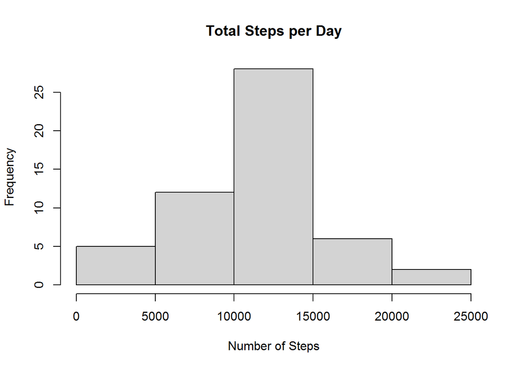

```r
# Calculate the total steps taken per day
totalSteps <- aggregate(steps ~ date, activityData, FUN = sum)

# Make a histogram of the total number of steps taken per day
hist(totalSteps$steps,
     main = "Total Steps per Day",
     xlab = "Number of Steps")
```

```r
# calculate and report the mean and median of total steps taken per day
meanSteps <- mean(totalSteps$steps, na.rm = TRUE)
medSteps <- median(totalSteps$steps, na.rm = TRUE)

meanSteps
```

```
## [1] 10766.19
```

```r
medSteps
```

```
## [1] 10765
```

## What is the average daily activity pattern?

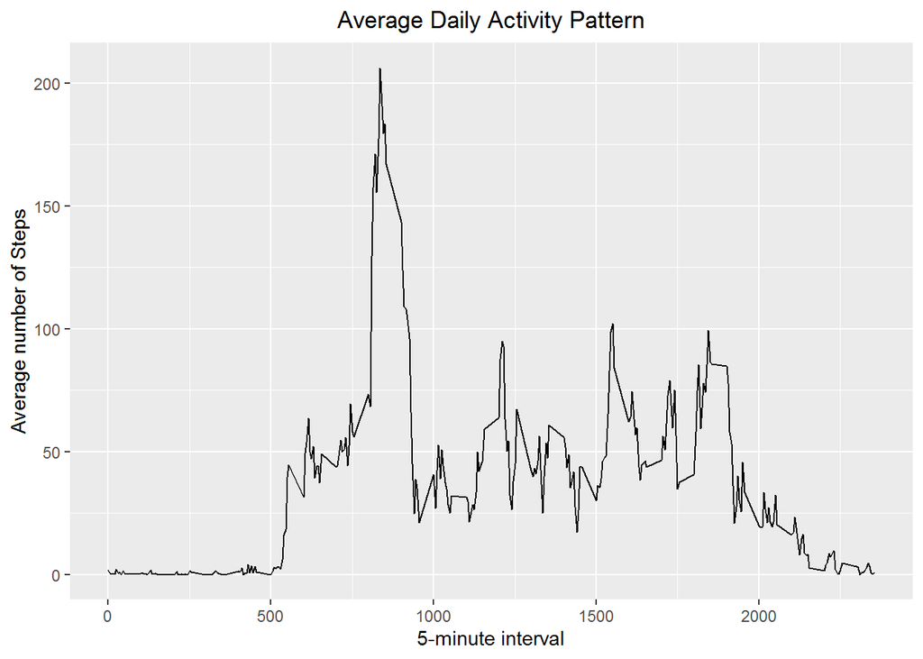

```r
# Make a time-series plot of the 5 minute interval and the average number of
# steps taken, averaged across all days.
library(ggplot2)
meanStepsByInt <- aggregate(steps ~ interval, activityData, mean)
ggplot(data = meanStepsByInt, aes(x = interval, y = steps)) +
    geom_line() +
    ggtitle("Average Daily Activity Pattern")+
    xlab("5-minute interval")+
    ylab("Average number of Steps")+
    theme(plot.title = element_text(hjust = 0.5))
```

```r
# Which 5-minute interval, on average across all the days in the dataset, contains the maximum number of steps?

maxInt <- meanStepsByInt[which.max(meanStepsByInt$steps),]

maxInt
```

```
##     interval    steps
## 104      835 206.1698
```